# Data Mining Principles - Homework #4

Luke Schwenke, Soheb Osmani, Ken Ma

2023-02-19

# Part 1 - Logistic Regression

```r
library(mltools)
library(data.table)
library(dplyr)
library(gains)
library(data.table)
library(MASS)
library(AUC)
library(rpart)
library(caret)

set.seed(101)
```

**Note:** the data has been pre-processed, loaded, and a **Step AIC model** has been run. Because the Step AIC model takes hours to run we have commented this section out and just loaded the workspace (.rdata) file. The Step AIC model was used to select the most meaningful coefficients after dummy-encoding non-ordered categorical variables.

```r
# data <- read.csv('diabetes_data_preprocess.csv', header = TRUE)
# data <- data[-which(data$gender %in% "Unknown/Invalid"),]
# mode(data$gender) <- "integer"
#
# data$id <- 1:nrow(data)
# train <- data %>% dplyr::sample_frac(0.7)
# test <- dplyr::anti_join(data, train, by = 'id')
# train$id <- NULL
# test$id <- NULL
#
# train_model <- glm(readmitted~., data=train, family=binomial(link=logit))
#
# train_summary <- summary(train_model)
#
# step_model <- stepAIC(train_model,direction="both", steps = 10)

load('DM_HW4_STEP_MODEL.rdata')
```

## Construct GLM Model

```r
# Set the expression to be the best terms from the Step Model output
expr <- attributes(step_model$model)$terms

# Create a new GLM model using the best terms
new_glm <- glm(expr, data=train, family=binomial(link=logit))

#### Confusion Matrix for Train
xp=new_glm$fitted.values
xp[xp>=0.5]=1
xp[xp<0.5]=0
print('Confusion Matrices - Threshold = 0.5, Training Set')
```

```
## [1] "Confusion Matrices - Threshold = 0.5, Training Set"
```

```r
table(train$readmitted, xp)
```

```
##    xp
##         0     1
##   0 24945  3558
##   1 14318  5219
```

```r
cm <- confusionMatrix(table(train$readmitted,xp))
cm$overall
```

```
##       Accuracy          Kappa  AccuracyLower  AccuracyUpper   AccuracyNull
##      0.6278934      0.1558011      0.6235530      0.6322184      0.8172981
## AccuracyPValue  McnemarPValue
##      1.0000000      0.0000000
```

```r
cm$byClass[c("Sensitivity", "Specificity")]
```

```
## Sensitivity Specificity
##   0.6353310   0.5946223
```

```r
round(prop.table(table(train$readmitted,xp),1),2)
```

```
##    xp
##        0    1
##   0 0.88 0.12
##   1 0.73 0.27
```

```r
round(prop.table(table(train$readmitted,xp),2),2)
```

```
##    xp
##        0    1
##   0 0.64 0.41
##   1 0.36 0.59
```

```r
#### Confusion Matrix for Train with different threshold
xp=new_glm$fitted.values
xp[xp>=0.33]=1
xp[xp<0.33]=0
print('Confusion Matrices - Threshold = 0.33, Training Set')
```

```
## [1] "Confusion Matrices - Threshold = 0.33, Training Set"
```

```r
table(train$readmitted,xp)
```

```
##    xp
##         0     1
##   0  8716 19787
##   1  2815 16722
```

```r
cm <- confusionMatrix(table(train$readmitted,xp))
cm$overall
```

```
##       Accuracy          Kappa  AccuracyLower  AccuracyUpper   AccuracyNull
##      0.5295171      0.1422683      0.5250417      0.5339889      0.7599709
## AccuracyPValue  McnemarPValue
##      1.0000000      0.0000000
```

```r
cm$byClass[c("Sensitivity", "Specificity")]
```

```
## Sensitivity Specificity
##   0.7558755   0.4580240
```

```r
round(prop.table(table(train$readmitted,xp),1),2)
```

```
##    xp
##        0    1
##   0 0.31 0.69
##   1 0.14 0.86
```

```r
round(prop.table(table(train$readmitted,xp),2),2)
```

```
##    xp
##        0    1
##   0 0.76 0.54
##   1 0.24 0.46
```

```r
#### Confusion Matrix for Test
test_predict=predict(new_glm, newdata=test,type="response")
test_xp <- test_predict
test_xp[test_xp>=0.5] <- 1
test_xp[test_xp<0.5] <- 0
print('Confusion Matrices - Threshold = 0.5, Test Set')
```

```
## [1] "Confusion Matrices - Threshold = 0.5, Test Set"
```

```r
table(test$readmitted,test_xp)
```

```
##    test_xp
##         0     1
##   0 10782  1594
##   1  6079  2134
```

```r
cm <- confusionMatrix(table(test$readmitted,test_xp))
cm$overall
```

```
##       Accuracy          Kappa  AccuracyLower  AccuracyUpper   AccuracyNull
##      0.6273253      0.1442863      0.6206788      0.6339357      0.8189324
## AccuracyPValue  McnemarPValue
##      1.0000000      0.0000000
```

```r
cm$byClass[c("Sensitivity", "Specificity")]
```

```
## Sensitivity Specificity
##   0.6394639   0.5724249
```

```r
round(prop.table(table(test$readmitted,test_xp),1),2)
```

```
##    test_xp
##        0    1
##   0 0.87 0.13
##   1 0.74 0.26
```

```r
round(prop.table(table(test$readmitted,test_xp),2),2)
```

```
##    test_xp
##        0    1
##   0 0.64 0.43
##   1 0.36 0.57
```

```r
### Confusion Matrix for Test with a new threshold of 33%
test_xp <- test_predict
test_xp[test_xp>=0.33] <- 1
test_xp[test_xp<0.33] <- 0
print('Confusion Matrices - Threshold = 0.33, Test Set')
```

```
## [1] "Confusion Matrices - Threshold = 0.33, Test Set"
```

```r
table(test$readmitted,test_xp)
```

```
##    test_xp
##        0    1
##   0 3712 8664
##   1 1221 6992
```

```r
cm <- confusionMatrix(table(test$readmitted,test_xp))
cm$overall
```

```
##       Accuracy          Kappa  AccuracyLower  AccuracyUpper   AccuracyNull
##      0.5198893      0.1312617      0.5130383      0.5267346      0.7604060
## AccuracyPValue  McnemarPValue
##      1.0000000      0.0000000
```

```r
cm$byClass[c("Sensitivity", "Specificity")]
```

```
## Sensitivity Specificity
##   0.7524833   0.4466019
```

```r
round(prop.table(table(test$readmitted,test_xp),1),2)
```

```
##    test_xp
##        0    1
##   0 0.30 0.70
##   1 0.15 0.85
```

```r
round(prop.table(table(test$readmitted,test_xp),2),2)
```

```
##    test_xp
##        0    1
##   0 0.75 0.55
##   1 0.25 0.45
```

## Gains & ROC

```r
## Gains chart
gains(as.numeric(test$readmitted)-1,test_predict,10)
```

```
## Depth                            Cume   Cume Pct                     Mean
##  of           Cume     Mean      Mean   of Total    Lift   Cume     Model
## File     N      N      Resp      Resp      Resp    Index   Lift     Score
## -------------------------------------------------------------------------
##   10  2058   2058     -0.39     -0.39       6.5%      65     65      0.65
##   20  2059   4117     -0.48     -0.44      14.5%      80     73      0.52
##   30  2059   6176     -0.52     -0.46      23.1%      86     77      0.47
##   40  2059   8235     -0.58     -0.49      32.7%      96     82      0.44
##   50  2059  10294     -0.58     -0.51      42.3%      96     85      0.41
##   60  2059  12353     -0.61     -0.53      52.5%     102     88      0.39
##   70  2059  14412     -0.65     -0.54      63.3%     108     90      0.36
##   80  2059  16471     -0.67     -0.56      74.4%     111     93      0.33
##   90  2059  18530     -0.72     -0.58      86.3%     119     96      0.30
##  100  2059  20589     -0.82     -0.60     100.0%     137    100      0.19
```

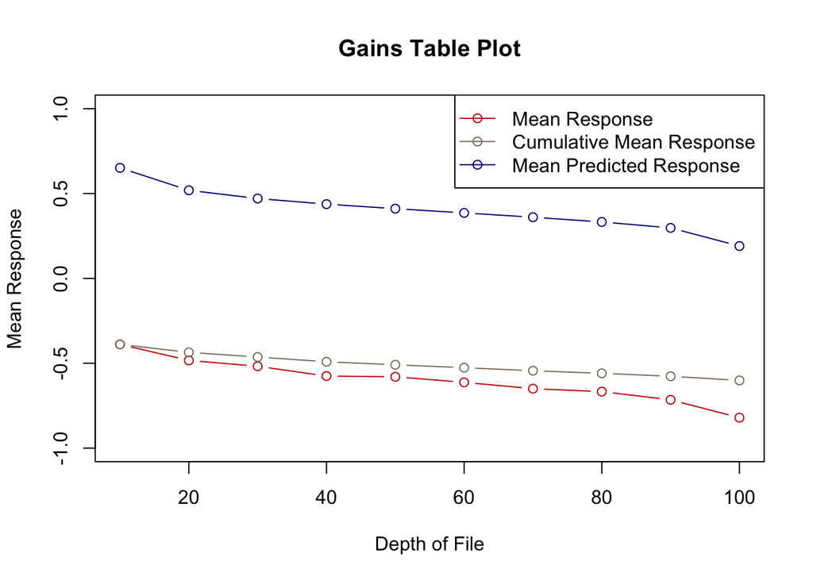

```r
plot(gains(as.numeric(test$readmitted)-1,test_predict,10),ylim = c(-1,1))
```

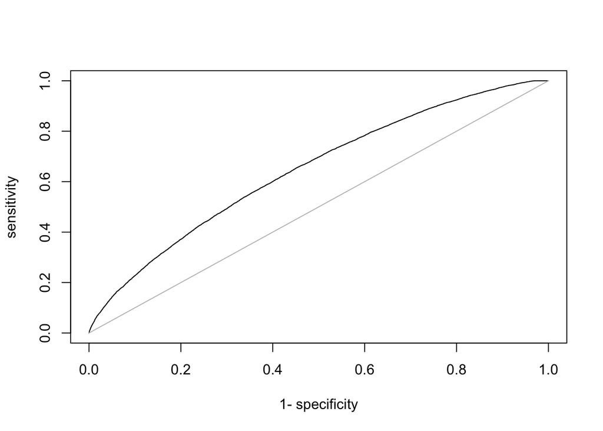

```r
## ROC
plot(roc(new_glm$fitted.values,factor(train$readmitted)))
```

For the train set, the confusion matrices show that with a threshold of 0.5, there was an overall accuracy of ~62.7%, with a sensitivity of ~63.5% and a specificity of ~59.5%. When considering the proportions of actual versus predicted values, the model correctly identified 59% of the readmissions, but also misclassified 41% of the non-readmissions. For the training set, with a threshold of 0.33, the model correctly identifies ~75.5% of the positive cases (sensitivity) but has a lower specificity of ~45.8%, meaning that many of the positive predictions are false positives. This suggests that the model is more likely to predict a patient as readmitted even if they are not actually readmitted. The overall accuracy is also lower at ~52.9%.

For the test set, the confusion matrices show that with a threshold of 0.5, there was an overall accuracy of ~62.7%, with a sensitivity of ~63.9% and a specificity of ~57.2%. When considering the proportions of actual versus predicted values, the model correctly identified 57% of the readmissions, but also misclassified 43% of the non-readmissions. with a threshold of 0.33 for the test set, the model has a higher sensitivity of ~75.2% and lower specificity of ~44.7%. The overall accuracy is also lower at ~51.9%.Overall, The model with a threshold of 0.33 is more sensitive to detecting true positive cases, but at the cost of lower precision and higher false positive predictions.

# Part 2 - Classification Tree

## Train Set

```r
#### TRAIN SET
train$readmitted <- factor(train$readmitted)
x <- rpart(expr, train, control=rpart.control(cp=0, minsplit=30, xval=10, maxsurrogate=0))

# Print cost-complexity parameters and then cross-val based on cp values and performance
printcp(x)
```

```
##
## Classification tree:
## rpart(formula = expr, data = train, control = rpart.control(cp = 0,
##     minsplit = 30, xval = 10, maxsurrogate = 0))
##
## Variables actually used in tree construction:
##  [1] A1Cresult_Normal            A1Cresult_Not.tested
##  [3] acarbose_Steady             admission_type_id_3
##  [5] admission_type_id_5         age
##  [7] change                      diabetesMed
##  [9] diag_1_Digestive            diag_1_Genitourinary
## [11] diag_1_Injury               diag_1_Musculoskeletal
## [13] diag_1_Neoplasms            diag_1_Other
## [15] diag_1_Respiratory          discharge_disposition_id_11
## [17] discharge_disposition_id_13 discharge_disposition_id_14
```

[output cut: 99 more lines]

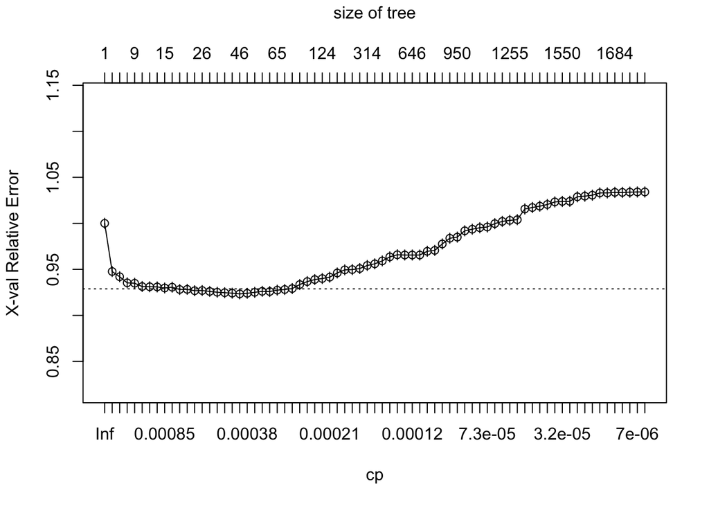

```r
plotcp(x, minline = TRUE)
```

```r
# Find lowest xerror value
cpthreshold <- x$cptable[,"CP"][which(x$cptable[,"xerror"] %in% min(x$cptable[,"xerror"]))]

# Build pruned tree and make prediction using the cp with lowest error
tree<-rpart(expr, train, control = rpart.control(cp=cpthreshold[[1]]))

# Confusion Matrix
table_train <- table(train$readmitted, predict(tree, type="class"))
table_train
```

```
##
##         0     1
##   0 25198  3305
##   1 14284  5253
```

## Test Set

```r
#### TEST SET
test_preds <- predict(tree, test[,-which(colnames(test) %in% "readmitted")], type = "class")
table_test <- table(test$readmitted, test_preds)
print('The below 2 confusion matrices are used to compare the Classification Tree Train and Test set results')
```

```
## [1] "The below 2 confusion matrices are used to compare the Classification Tree Train and Test set results"
```

```r
table_train
```

```
##
##         0     1
##   0 25198  3305
##   1 14284  5253
```

```r
table_test
```

```
##    test_preds
##         0     1
##   0 10828  1548
##   1  6180  2033
```

```r
#Num_interactions
num_interactions <- sum(tree$frame$var != "<leaf>")
print(num_interactions)
```

```
## [1] 44
```

```r
# Accuracy Comparison
sum(diag(table_train))/sum(table_train)
```

```
## [1] 0.6338676
```

```r
sum(diag(table_test))/sum(table_test)
```

```
## [1] 0.6246539
```

```r
# COMPARE LOGISTIC & CLASSIFICATION TREE CONFUSION MATRICES - TEST SETS
print('The below 2 confusion matrices are used to compare the Classification Tree Test and Logistic Reg. Test set results')
```

```
## [1] "The below 2 confusion matrices are used to compare the Classification Tree Test and Logistic Reg. Test set results"
```

```r
round(prop.table(table(test$readmitted, test_xp),2),2)
```

```
##    test_xp
##        0    1
##   0 0.75 0.55
##   1 0.25 0.45
```

```r
round(prop.table(table(test$readmitted, test_preds),2),2)
```

```
##    test_preds
##        0    1
##   0 0.64 0.43
##   1 0.36 0.57
```

```r
#summary(tree)

# Accuracy Comparison
sum(diag(table(test$readmitted, test_xp)))/sum(table(test$readmitted, test_xp))
```

```
## [1] 0.5198893
```

```r
sum(diag(table(test$readmitted, test_preds)))/sum(table(test$readmitted, test_preds))
```

```
## [1] 0.6246539
```

### **Part 2 - Classification Tree Summary:**

- Interaction depth is the number of splits in a tree, the number of interactions is 44 for this tree. This tree was constructed based on 58 predictor variables and the 5 most important variables were number of inpatient visits, discharge disposition id, number of diagnoses, number of outpatient visits, and diabetes meds.
- The results between the train and test set for the classification tree are stable. Taking a look at the accuracy specifically, they only differ by 1%.
- When comparing the test sets between the Classification Tree and Logistic Regression, **the Classification Tree performs better with an accuracy of 62.4% compared to 52%**.